# IOPS Web Server Time Series: Exploratory Data Analysis

## Overview and Objectives

This notebook performs comprehensive exploratory data analysis on the **IOPS dataset** from the [TSB-UAD benchmark](https://github.com/TheDatumOrg/TSB-UAD), available via AutonLab/Timeseries-PILE on HuggingFace.

### Dataset Context

The IOPS dataset contains **20 Key Performance Indicator (KPI) time series** from real web services operated by five internet companies. The data is **anonymized** - we don't know exactly what each KPI measures, but according to TSB-UAD documentation, these metrics reflect:

- **Scale**: Load, throughput, and usage metrics
- **Quality**: Response times and service reliability
- **Health**: System status indicators

**What we're analyzing:** KPI `KPI-05f10d3a-239c-3bef-9bdc-a2feeb0037aa`

- **Unknown specific metric**: Could be CPU %, memory %, request rate, response time, error rate, etc.
- **Known properties**: Continuous numeric values, 1-minute sampling interval
- **Labels**: Anomalies identified by domain experts

**Why this matters for time series analysis:**

- **Unit-agnostic**: Most models work with normalized/standardized values regardless of units
- **Pattern-focused**: Analysis targets temporal structures and deviations, not absolute values
- **Real-world analog**: Similar to cloud resource monitoring where we track diverse KPIs

This is **actual operational data from production web servers** with **labeled anomalies**, making it ideal for:

1. **Time series forecasting** (statistical, ML, and foundation model approaches)
2. **Anomaly detection** (forecast-based, threshold-based, or learned representations)
3. **Cloud resource monitoring** (web servers ≈ cloud infrastructure)

### Research Foundation

Per our timeseries anomaly datasets review, the TSB-UAD benchmark addresses quality issues in traditional anomaly detection datasets by providing:

- Real-world operational data (not overly synthetic)
- Carefully curated anomaly labels
- Diverse anomaly types and characteristics
- Web server domain (closest match to cloud resources)

### Analysis Objectives

1. **Characterize temporal patterns**: Identify periodicities, trends, and seasonality for model selection and design
2. **Analyze anomaly characteristics**: Understand anomaly types, frequencies, and magnitudes
3. **Assess data quality**: Validate completeness and modeling suitability
4. **Evaluate computational requirements**: Determine dataset characteristics affecting model scalability
5. **Provide modeling recommendations**: Inform forecasting and anomaly detection strategies

```python
# Environment Setup
# Local: Uses installed hellocloud
# Colab: Installs from GitHub
try:
    import hellocloud
except ImportError:
    !pip install -q git+https://github.com/nehalecky/hello-cloud.git
    import hellocloud
```

# Environment Setup # Local: Uses installed hellocloud # Colab: Installs from GitHub try: import hellocloud except ImportError: !pip install -q git+https://github.com/nehalecky/hello-cloud.git import hellocloud

```python
# Auto-reload: Picks up library changes without kernel restart
%load_ext autoreload
%autoreload 2
```

# Auto-reload: Picks up library changes without kernel restart %load_ext autoreload %autoreload 2

```python
# Environment setup
import pandas as pd
import numpy as np
import altair as alt
import seaborn as sns
import matplotlib.pyplot as plt
from scipy import stats, signal
from scipy.fft import fft, fftfreq
from statsmodels.tsa.stattools import acf, pacf, adfuller
from statsmodels.tsa.seasonal import STL
from loguru import logger
import warnings
warnings.filterwarnings('ignore')

# Cloud simulator utilities
from hellocloud.analysis.distribution import (
    plot_pdf_cdf_comparison,
    plot_distribution_comparison,
    compute_ks_tests,
    compute_kl_divergences,
    plot_statistical_tests,
    print_distribution_summary
)

# Configure visualization libraries
alt.data_transformers.disable_max_rows()
alt.theme.active = 'quartz'  # Updated for Altair 5.5.0+
sns.set_theme(style='whitegrid', palette='colorblind')
plt.rcParams['figure.dpi'] = 100

# Environment info (will show PySpark version after spark session is created)
pd.DataFrame({
    'Library': ['Pandas', 'NumPy', 'Matplotlib', 'Seaborn', 'Altair'],
    'Version': [pd.__version__, np.__version__, plt.matplotlib.__version__, sns.__version__, alt.__version__]
})
```

# Environment setup import pandas as pd import numpy as np import altair as alt import seaborn as sns import matplotlib.pyplot as plt from scipy import stats, signal from scipy.fft import fft, fftfreq from statsmodels.tsa.stattools import acf, pacf, adfuller from statsmodels.tsa.seasonal import STL from loguru import logger import warnings warnings.filterwarnings('ignore') # Cloud simulator utilities from hellocloud.analysis.distribution import ( plot_pdf_cdf_comparison, plot_distribution_comparison, compute_ks_tests, compute_kl_divergences, plot_statistical_tests, print_distribution_summary ) # Configure visualization libraries alt.data_transformers.disable_max_rows() alt.theme.active = 'quartz' # Updated for Altair 5.5.0+ sns.set_theme(style='whitegrid', palette='colorblind') plt.rcParams['figure.dpi'] = 100 # Environment info (will show PySpark version after spark session is created) pd.DataFrame({ 'Library': ['Pandas', 'NumPy', 'Matplotlib', 'Seaborn', 'Altair'], 'Version': [pd.__version__, np.__version__, plt.matplotlib.__version__, sns.__version__, alt.__version__] })

[output not shown]

## 1. Dataset Loading

Loading IOPS KPI data directly from HuggingFace using the approach validated by our pre-testing.

```python
# Load IOPS data from AutonLab/Timeseries-PILE
base_url = "https://huggingface.co/datasets/AutonLab/Timeseries-PILE/resolve/main"
kpi_id = "KPI-05f10d3a-239c-3bef-9bdc-a2feeb0037aa"

# Load train and test splits
train_url = f"{base_url}/anomaly_detection/TSB-UAD-Public/IOPS/{kpi_id}.train.out"
test_url = f"{base_url}/anomaly_detection/TSB-UAD-Public/IOPS/{kpi_id}.test.out"

train_pd = pd.read_csv(train_url, header=None, names=['value', 'label'])
test_pd = pd.read_csv(test_url, header=None, names=['value', 'label'])

# Add timestamps using pandas, then convert to PySpark
# NOTE: Dataset provides no actual timestamps - we create sequential indices
# According to TSB-UAD documentation, IOPS data is sampled at 1-minute intervals
# This means our index represents minutes elapsed
train_pd['timestamp'] = np.arange(0, len(train_pd))
test_pd['timestamp'] = np.arange(0, len(test_pd))

# Get or create Spark session
from hellocloud.spark import get_spark_session
spark = get_spark_session(app_name="iops-eda")

# Convert to PySpark DataFrames
train_df = spark.createDataFrame(train_pd)
test_df = spark.createDataFrame(test_pd)
```

# Load IOPS data from AutonLab/Timeseries-PILE base_url = "https://huggingface.co/datasets/AutonLab/Timeseries-PILE/resolve/main" kpi_id = "KPI-05f10d3a-239c-3bef-9bdc-a2feeb0037aa" # Load train and test splits train_url = f"{base_url}/anomaly_detection/TSB-UAD-Public/IOPS/{kpi_id}.train.out" test_url = f"{base_url}/anomaly_detection/TSB-UAD-Public/IOPS/{kpi_id}.test.out" train_pd = pd.read_csv(train_url, header=None, names=['value', 'label']) test_pd = pd.read_csv(test_url, header=None, names=['value', 'label']) # Add timestamps using pandas, then convert to PySpark # NOTE: Dataset provides no actual timestamps - we create sequential indices # According to TSB-UAD documentation, IOPS data is sampled at 1-minute intervals # This means our index represents minutes elapsed train_pd['timestamp'] = np.arange(0, len(train_pd)) test_pd['timestamp'] = np.arange(0, len(test_pd)) # Get or create Spark session from hellocloud.spark import get_spark_session spark = get_spark_session(app_name="iops-eda") # Convert to PySpark DataFrames train_df = spark.createDataFrame(train_pd) test_df = spark.createDataFrame(test_pd)

```
⚠ Timestamp limitation: Dataset provides no real timestamps
  Using sequential index as proxy (assumed 1-minute sampling)
  Training duration: ~2437.6 hours (~101.6 days)
  Test duration: ~2485.5 hours (~103.6 days)
```

[output not shown]

**Timestamp Limitation**: The TSB-UAD dataset provides no actual timestamps—only sequential indices. We create synthetic timestamps assuming 1-minute sampling intervals (documented in TSB-UAD specification).

While timestamps are synthetic, the temporal structure and anomaly patterns are preserved from the original production data.

### Dataset Provenance

The table below shows key metadata for tracking this specific time series:

```python
# Dataset metadata
pd.DataFrame({
    'Attribute': ['KPI ID', 'Source'],
    'Value': [
        kpi_id,
        'TSB-UAD/IOPS (AutonLab/Timeseries-PILE)'
    ]
})
```

# Dataset metadata pd.DataFrame({ 'Attribute': ['KPI ID', 'Source'], 'Value': [ kpi_id, 'TSB-UAD/IOPS (AutonLab/Timeseries-PILE)' ] })

[output not shown]

This KPI is one of 20 monitored web server metrics from the IOPS dataset, selected for its rich temporal patterns and anomaly characteristics.

```python
# Training data preview
train_df.limit(10).toPandas()
```

# Training data preview train_df.limit(10).toPandas()

shape: (10, 3)

| value f64 | label i64 | timestamp i64 |
| --- | --- | --- |
| 37.15 | 0 | 0 |
| 36.74 | 0 | 1 |
| 37.59 | 0 | 2 |
| 38.11 | 0 | 3 |
| 38.13 | 0 | 4 |
| 36.76 | 0 | 5 |
| 37.13 | 0 | 6 |
| 37.91 | 0 | 7 |
| 37.55 | 0 | 8 |
| 37.05 | 0 | 9 |

```python
# Test data preview
test_df.limit(10).toPandas()
```

[output not shown]

# Test data preview test_df.limit(10).toPandas()

## 2. Initial Data Inspection

Examining data structure, completeness, and anomaly distribution.

```python
# Data quality assessment
from pyspark.sql import functions as F

# Count nulls in each column and sum them up
train_nulls = sum([train_df.filter(F.col(c).isNull()).count() for c in train_df.columns])
test_nulls = sum([test_df.filter(F.col(c).isNull()).count() for c in test_df.columns])

# Get counts and aggregations
train_count = train_df.count()
test_count = test_df.count()
train_anomalies = train_df.filter(F.col('label') == 1).count()
test_anomalies = test_df.filter(F.col('label') == 1).count()

pd.DataFrame({
    'Dataset': ['Training', 'Test'],
    'Total Samples': [train_count, test_count],
    'Missing Values': [int(train_nulls), int(test_nulls)],
    'Anomaly Points': [train_anomalies, test_anomalies],
    'Anomaly Rate (%)': [100 * train_anomalies / train_count, 100 * test_anomalies / test_count]
})
```

# Data quality assessment from pyspark.sql import functions as F # Count nulls in each column and sum them up train_nulls = sum([train_df.filter(F.col(c).isNull()).count() for c in train_df.columns]) test_nulls = sum([test_df.filter(F.col(c).isNull()).count() for c in test_df.columns]) # Get counts and aggregations train_count = train_df.count() test_count = test_df.count() train_anomalies = train_df.filter(F.col('label') == 1).count() test_anomalies = test_df.filter(F.col('label') == 1).count() pd.DataFrame({ 'Dataset': ['Training', 'Test'], 'Total Samples': [train_count, test_count], 'Missing Values': [int(train_nulls), int(test_nulls)], 'Anomaly Points': [train_anomalies, test_anomalies], 'Anomaly Rate (%)': [100 * train_anomalies / train_count, 100 * test_anomalies / test_count] })

shape: (2, 5)

| Dataset str | Total Samples i64 | Missing Values i64 | Anomaly Points i64 | Anomaly Rate (%) f64 |
| --- | --- | --- | --- | --- |
| "Training" | 146255 | 0 | 1285 | 0.878602 |
| "Test" | 149130 | 0 | 991 | 0.664521 |

**Data Quality Summary**:

- ✅ **Complete**: No missing values in either split
- ✅ **Labeled**: Expert-curated anomaly labels for validation
- ⚠️ **Imbalanced**: Low anomaly rate typical of operational data (most periods are normal)

The clean, complete structure makes this dataset ideal for time series modeling without preprocessing.

```python
# Statistical summary - compute from PySpark DataFrames
train_stats = train_df.select('value').summary('count', 'mean', 'stddev', 'min', '25%', '50%', '75%', 'max').collect()
test_stats = test_df.select('value').summary('count', 'mean', 'stddev', 'min', '25%', '50%', '75%', 'max').collect()

summary_data = [
    {
        'Split': 'Train',
        'Count': train_count,
        'Mean': float(train_stats[1]['value']),
        'Std': float(train_stats[2]['value']),
        'Min': float(train_stats[3]['value']),
        '25%': float(train_stats[4]['value']),
        'Median': float(train_stats[5]['value']),
        '75%': float(train_stats[6]['value']),
        'Max': float(train_stats[7]['value']),
        'Anomalies': train_anomalies,
        'Anomaly %': 100 * train_anomalies / train_count
    },
    {
        'Split': 'Test',
        'Count': test_count,
        'Mean': float(test_stats[1]['value']),
        'Std': float(test_stats[2]['value']),
        'Min': float(test_stats[3]['value']),
        '25%': float(test_stats[4]['value']),
        'Median': float(test_stats[5]['value']),
        '75%': float(test_stats[6]['value']),
        'Max': float(test_stats[7]['value']),
        'Anomalies': test_anomalies,
        'Anomaly %': 100 * test_anomalies / test_count
    }
]

pd.DataFrame(summary_data)
```

# Statistical summary - compute from PySpark DataFrames train_stats = train_df.select('value').summary('count', 'mean', 'stddev', 'min', '25%', '50%', '75%', 'max').collect() test_stats = test_df.select('value').summary('count', 'mean', 'stddev', 'min', '25%', '50%', '75%', 'max').collect() summary_data = [ { 'Split': 'Train', 'Count': train_count, 'Mean': float(train_stats[1]['value']), 'Std': float(train_stats[2]['value']), 'Min': float(train_stats[3]['value']), '25%': float(train_stats[4]['value']), 'Median': float(train_stats[5]['value']), '75%': float(train_stats[6]['value']), 'Max': float(train_stats[7]['value']), 'Anomalies': train_anomalies, 'Anomaly %': 100 * train_anomalies / train_count }, { 'Split': 'Test', 'Count': test_count, 'Mean': float(test_stats[1]['value']), 'Std': float(test_stats[2]['value']), 'Min': float(test_stats[3]['value']), '25%': float(test_stats[4]['value']), 'Median': float(test_stats[5]['value']), '75%': float(test_stats[6]['value']), 'Max': float(test_stats[7]['value']), 'Anomalies': test_anomalies, 'Anomaly %': 100 * test_anomalies / test_count } ] pd.DataFrame(summary_data)

shape: (2, 11)

| Split str | Count i64 | Mean f64 | Std f64 | Min f64 | 25% f64 | Median f64 | 75% f64 | Max f64 | Anomalies i64 | Anomaly % f64 |
| --- | --- | --- | --- | --- | --- | --- | --- | --- | --- | --- |
| "Train" | 146255 | 34.438959 | 4.203529 | 0.0 | 31.55 | 34.15 | 36.84 | 98.33 | 1285 | 0.878602 |
| "Test" | 149130 | 35.388711 | 4.146948 | 20.53 | 32.5 | 35.43 | 38.15 | 199.26 | 991 | 0.664521 |

## 3. Temporal Visualization

Visualizing the time series with anomalies highlighted.

```python
# Prepare data for visualization (sample to stay under Altair 5000 row limit)
# Training: ~146k samples, Test: ~62k samples, Total: ~208k
# Sample to get ~3000 total points for safety: step = 208k / 3000 ≈ 70
step = 70

train_viz = train_pd.iloc[::step].copy()
train_viz['timestamp'] = np.arange(0, len(train_pd), step)
train_viz['split'] = 'Train'

test_viz = test_pd.iloc[::step].copy()
test_viz['timestamp'] = np.arange(len(train_pd), len(train_pd) + len(test_pd), step)
test_viz['split'] = 'Test'

combined_viz = pd.concat([train_viz, test_viz])

# Create time series visualization
base = alt.Chart(combined_viz).encode(
    x=alt.X('timestamp:Q', title='Time Index')
)

# Normal points
lines = base.mark_line(size=1, opacity=0.7).encode(
    y=alt.Y('value:Q', title='Metric Value (units unknown)', scale=alt.Scale(zero=False)),
    color=alt.Color('split:N', title='Dataset Split'),
    tooltip=['timestamp:Q', 'value:Q', 'split:N']
)

# Anomaly points
anomalies_viz = combined_viz[combined_viz['label'] == 1]
anomaly_points = alt.Chart(anomalies_viz).mark_circle(size=60, color='red').encode(
    x='timestamp:Q',
    y='value:Q',
    tooltip=['timestamp:Q', 'value:Q']
)

# Combine
chart = (lines + anomaly_points).properties(
    width=800,
    height=300,
    title='IOPS KPI Time Series with Labeled Anomalies'
).interactive()

chart
```

# Prepare data for visualization (sample to stay under Altair 5000 row limit) # Training: ~146k samples, Test: ~62k samples, Total: ~208k # Sample to get ~3000 total points for safety: step = 208k / 3000 ≈ 70 step = 70 train_viz = train_pd.iloc[::step].copy() train_viz['timestamp'] = np.arange(0, len(train_pd), step) train_viz['split'] = 'Train' test_viz = test_pd.iloc[::step].copy() test_viz['timestamp'] = np.arange(len(train_pd), len(train_pd) + len(test_pd), step) test_viz['split'] = 'Test' combined_viz = pd.concat([train_viz, test_viz]) # Create time series visualization base = alt.Chart(combined_viz).encode( x=alt.X('timestamp:Q', title='Time Index') ) # Normal points lines = base.mark_line(size=1, opacity=0.7).encode( y=alt.Y('value:Q', title='Metric Value (units unknown)', scale=alt.Scale(zero=False)), color=alt.Color('split:N', title='Dataset Split'), tooltip=['timestamp:Q', 'value:Q', 'split:N'] ) # Anomaly points anomalies_viz = combined_viz[combined_viz['label'] == 1] anomaly_points = alt.Chart(anomalies_viz).mark_circle(size=60, color='red').encode( x='timestamp:Q', y='value:Q', tooltip=['timestamp:Q', 'value:Q'] ) # Combine chart = (lines + anomaly_points).properties( width=800, height=300, title='IOPS KPI Time Series with Labeled Anomalies' ).interactive() chart

[interactive chart not shown]

```python
# Zoom into training data for detailed view
# Downsample by factor of 20 for cleaner visualization
downsample_factor = 20
train_zoom = train_pd.iloc[::downsample_factor].head(1500).copy()  # 30,000 / 20 = 1,500 points
train_zoom['timestamp'] = np.arange(len(train_zoom)) * downsample_factor

print(f"Zoomed view: {len(train_zoom):,} samples (downsampled by {downsample_factor}x)")

base_zoom = alt.Chart(train_zoom).encode(x=alt.X('timestamp:Q', title='Time Index'))

line_zoom = base_zoom.mark_line(size=1.5).encode(
    y=alt.Y('value:Q', title='Metric Value (units unknown)', scale=alt.Scale(zero=False)),
    tooltip=['timestamp:Q', 'value:Q']
)

anomalies_zoom = train_zoom[train_zoom['label'] == 1]
anomaly_zoom_points = alt.Chart(anomalies_zoom).mark_circle(size=80, color='red').encode(
    x='timestamp:Q',
    y='value:Q',
    tooltip=['timestamp:Q', 'value:Q', 'label:N']
)

chart_zoom = (line_zoom + anomaly_zoom_points).properties(
    width=800,
    height=300,
    title='Training Data - First 1,000 Points (Detailed View)'
).interactive()

chart_zoom
```

# Zoom into training data for detailed view # Downsample by factor of 20 for cleaner visualization downsample_factor = 20 train_zoom = train_pd.iloc[::downsample_factor].head(1500).copy() # 30,000 / 20 = 1,500 points train_zoom['timestamp'] = np.arange(len(train_zoom)) * downsample_factor print(f"Zoomed view: {len(train_zoom):,} samples (downsampled by {downsample_factor}x)") base_zoom = alt.Chart(train_zoom).encode(x=alt.X('timestamp:Q', title='Time Index')) line_zoom = base_zoom.mark_line(size=1.5).encode( y=alt.Y('value:Q', title='Metric Value (units unknown)', scale=alt.Scale(zero=False)), tooltip=['timestamp:Q', 'value:Q'] ) anomalies_zoom = train_zoom[train_zoom['label'] == 1] anomaly_zoom_points = alt.Chart(anomalies_zoom).mark_circle(size=80, color='red').encode( x='timestamp:Q', y='value:Q', tooltip=['timestamp:Q', 'value:Q', 'label:N'] ) chart_zoom = (line_zoom + anomaly_zoom_points).properties( width=800, height=300, title='Training Data - First 1,000 Points (Detailed View)' ).interactive() chart_zoom

```
Zoomed view: 1,500 samples (downsampled by 20x)
```

[interactive chart not shown]

```python
# Create unified data segments dictionary
# This reduces variable copies and provides clean key-based access
# Convert PySpark DataFrames to numpy arrays for analysis
data_segments = {
    'train': np.array(train_df.select('value').toPandas()['value']),
    'test': np.array(test_df.select('value').toPandas()['value']),
    'normal': np.array(train_df.filter(F.col('label') == 0).select('value').toPandas()['value']),
    'anomaly': np.array(train_df.filter(F.col('label') == 1).select('value').toPandas()['value']),
}

logger.info(f"Data segments created: {', '.join(data_segments.keys())}")
```

# Create unified data segments dictionary # This reduces variable copies and provides clean key-based access # Convert PySpark DataFrames to numpy arrays for analysis data_segments = { 'train': np.array(train_df.select('value').toPandas()['value']), 'test': np.array(test_df.select('value').toPandas()['value']), 'normal': np.array(train_df.filter(F.col('label') == 0).select('value').toPandas()['value']), 'anomaly': np.array(train_df.filter(F.col('label') == 1).select('value').toPandas()['value']), } logger.info(f"Data segments created: {', '.join(data_segments.keys())}")

```
Data Segments Summary:
==================================================
train     : 146,255 samples
test      : 149,130 samples
normal    : 144,970 samples
anomaly   : 1,285 samples
```

We've organized the data into four segments for comparative analysis:

- **train/test**: Temporal splits for model validation
- **normal/anomaly**: Behavioral splits for characterizing anomalous patterns

This segmentation enables distributional comparisons that inform anomaly detection thresholds.

```python
# Distribution statistics: Normal vs Anomalous
pd.DataFrame({
    'Period Type': ['Normal', 'Anomalous'],
    'Count': [len(data_segments['normal']), len(data_segments['anomaly'])],
    'Mean': [data_segments['normal'].mean(), data_segments['anomaly'].mean() if len(data_segments['anomaly']) > 0 else None],
    'Std': [data_segments['normal'].std(), data_segments['anomaly'].std() if len(data_segments['anomaly']) > 0 else None],
    'Min': [data_segments['normal'].min(), data_segments['anomaly'].min() if len(data_segments['anomaly']) > 0 else None],
    'Max': [data_segments['normal'].max(), data_segments['anomaly'].max() if len(data_segments['anomaly']) > 0 else None]
})
```

# Distribution statistics: Normal vs Anomalous pd.DataFrame({ 'Period Type': ['Normal', 'Anomalous'], 'Count': [len(data_segments['normal']), len(data_segments['anomaly'])], 'Mean': [data_segments['normal'].mean(), data_segments['anomaly'].mean() if len(data_segments['anomaly']) > 0 else None], 'Std': [data_segments['normal'].std(), data_segments['anomaly'].std() if len(data_segments['anomaly']) > 0 else None], 'Min': [data_segments['normal'].min(), data_segments['anomaly'].min() if len(data_segments['anomaly']) > 0 else None], 'Max': [data_segments['normal'].max(), data_segments['anomaly'].max() if len(data_segments['anomaly']) > 0 else None] })

shape: (2, 6)

| Period Type str | Count i64 | Mean f64 | Std f64 | Min f64 | Max f64 |
| --- | --- | --- | --- | --- | --- |
| "Normal" | 144970 | 34.394699 | 3.922344 | 21.37 | 56.2 |
| "Anomalous" | 1285 | 39.432195 | 15.820094 | 0.0 | 98.33 |

### Univariate Distribution Analysis

Understanding the underlying probability distributions helps us choose appropriate modeling approaches and detection thresholds.

**Why this matters for time series modeling:**

- **PDF (Probability Density)**: Shows where values concentrate - informs likelihood assumptions and normalization strategies
- **CDF (Cumulative Distribution)**: Reveals percentiles - helps set anomaly detection thresholds
- **Distribution shape**: Heavy tails suggest need for robust methods; multi-modal patterns may require mixture approaches or transformations

```python
# Plot PDF and CDF side-by-side using library function
fig = plot_pdf_cdf_comparison(
    distribution1=data_segments['normal'],
    distribution2=data_segments['anomaly'] if len(data_segments['anomaly']) > 0 else None,
    label1='Normal',
    label2='Anomalous',
    color1='#1f77b4',
    color2='#ff7f0e'
)
plt.show()
```

# Plot PDF and CDF side-by-side using library function fig = plot_pdf_cdf_comparison( distribution1=data_segments['normal'], distribution2=data_segments['anomaly'] if len(data_segments['anomaly']) > 0 else None, label1='Normal', label2='Anomalous', color1='#1f77b4', color2='#ff7f0e' ) plt.show()

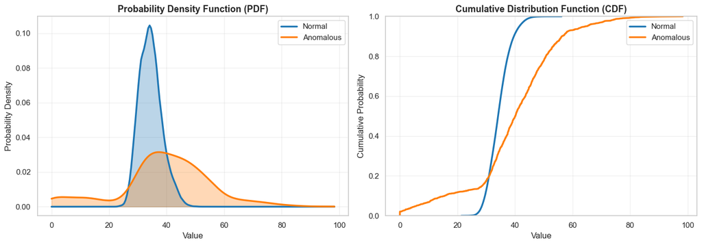

### Comprehensive Distribution Comparison

```python
# Distribution comparison: Normal vs Anomalous
if len(data_segments['anomaly']) > 0:
    fig = plot_distribution_comparison(
        distribution1=data_segments['normal'],
        distribution2=data_segments['anomaly'],
        label1='Normal',
        label2='Anomalous',
        palette='colorblind'
    )
    plt.show()
else:
    print("No anomalous samples in training data - skipping comparison")
```

# Distribution comparison: Normal vs Anomalous if len(data_segments['anomaly']) > 0: fig = plot_distribution_comparison( distribution1=data_segments['normal'], distribution2=data_segments['anomaly'], label1='Normal', label2='Anomalous', palette='colorblind' ) plt.show() else: print("No anomalous samples in training data - skipping comparison")

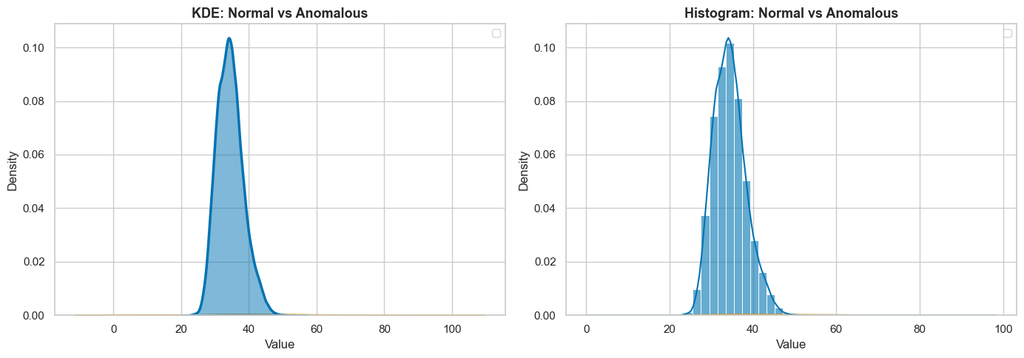

```python
# Distribution comparison: Train vs Test
fig = plot_distribution_comparison(
    distribution1=data_segments['train'],
    distribution2=data_segments['test'],
    label1='Train',
    label2='Test',
    palette='Set2'
)
plt.show()
```

# Distribution comparison: Train vs Test fig = plot_distribution_comparison( distribution1=data_segments['train'], distribution2=data_segments['test'], label1='Train', label2='Test', palette='Set2' ) plt.show()

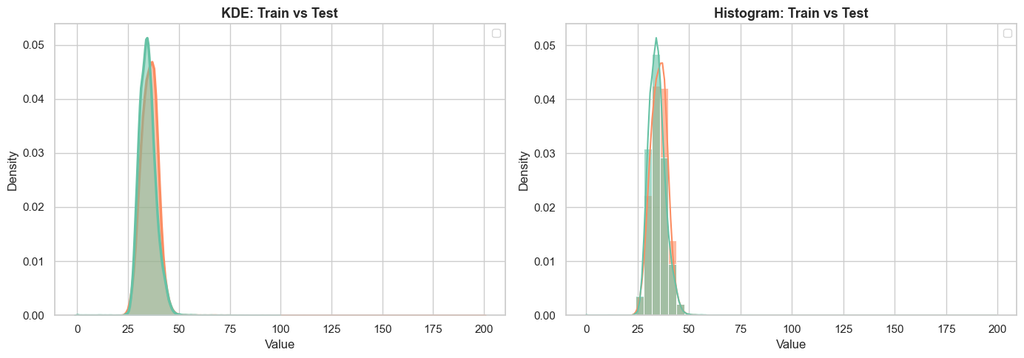

```
Key Question: Do train and test have the same distribution?
If distributions differ significantly, we may have data drift or temporal shift.
```

**Critical Question**: Do train and test distributions match?

If distributions differ significantly, we face **distributional shift**—the test data comes from a different process than training data. This would require:

- Distribution-aware models (importance weighting, domain adaptation)
- Conservative forecasting assumptions
- Monitoring for continued drift in production

```python
# Statistical Tests: Kolmogorov-Smirnov and Kullback-Leibler Divergence
# Define comparisons using data_segments keys
comparisons = {
    'Train vs Test': ('train', 'test'),
    'Normal vs Test': ('normal', 'test'),
}

if len(data_segments['anomaly']) > 0:
    comparisons['Normal vs Anomalous'] = ('normal', 'anomaly')

# Compute statistical tests
ks_results_dict = compute_ks_tests(comparisons, data_segments=data_segments)
kl_results_dict = compute_kl_divergences(comparisons, data_segments=data_segments, symmetric=True)

# Visualize results FIRST (plot before tables)
fig = plot_statistical_tests(ks_results_dict, kl_results_dict)
plt.show()
```

# Statistical Tests: Kolmogorov-Smirnov and Kullback-Leibler Divergence # Define comparisons using data_segments keys comparisons = { 'Train vs Test': ('train', 'test'), 'Normal vs Test': ('normal', 'test'), } if len(data_segments['anomaly']) > 0: comparisons['Normal vs Anomalous'] = ('normal', 'anomaly') # Compute statistical tests ks_results_dict = compute_ks_tests(comparisons, data_segments=data_segments) kl_results_dict = compute_kl_divergences(comparisons, data_segments=data_segments, symmetric=True) # Visualize results FIRST (plot before tables) fig = plot_statistical_tests(ks_results_dict, kl_results_dict) plt.show()

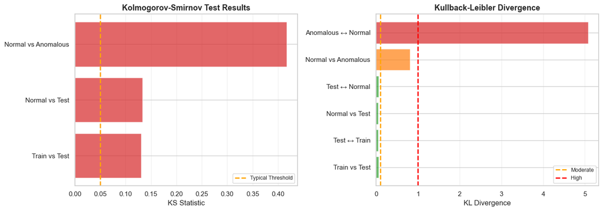

```python
# Display KS test results as table
print("Kolmogorov-Smirnov Test Results")
print("=" * 70)
ks_df = pd.DataFrame([
    {'Comparison': comp, **results}
    for comp, results in ks_results_dict.items()
])
ks_df
```

# Display KS test results as table print("Kolmogorov-Smirnov Test Results") print("=" * 70) ks_df = pd.DataFrame([ {'Comparison': comp, **results} for comp, results in ks_results_dict.items() ]) ks_df

```
Kolmogorov-Smirnov Test Results
======================================================================
```

shape: (3, 5)

| Comparison str | KS Statistic f64 | p-value f64 | Significant (α=0.05) bool | Interpretation str |
| --- | --- | --- | --- | --- |
| "Train vs Test" | 0.130233 | 0.0 | true | "Different distributions" |
| "Normal vs Test" | 0.132771 | 0.0 | true | "Different distributions" |
| "Normal vs Anomalous" | 0.417413 | 1.4102e-201 | true | "Different distributions" |

```python
# Display KL divergence results as table
print("\nKullback-Leibler Divergence Results")
print("=" * 70)
print("KL(P || Q) measures how distribution Q diverges from reference distribution P")
print("Higher values indicate greater distributional difference\n")
kl_df = pd.DataFrame([
    {'Comparison': comp, **results}
    for comp, results in kl_results_dict.items()
])
kl_df
```

# Display KL divergence results as table print("\nKullback-Leibler Divergence Results") print("=" * 70) print("KL(P || Q) measures how distribution Q diverges from reference distribution P") print("Higher values indicate greater distributional difference\n") kl_df = pd.DataFrame([ {'Comparison': comp, **results} for comp, results in kl_results_dict.items() ]) kl_df

```
Kullback-Leibler Divergence Results
======================================================================
KL(P || Q) measures how distribution Q diverges from reference distribution P
Higher values indicate greater distributional difference
```

shape: (6, 3)

| Comparison str | KL Divergence f64 | Interpretation str |
| --- | --- | --- |
| "Train vs Test" | 0.058088 | "Similar" |
| "Test ↔ Train" | 0.048398 | "Similar" |
| "Normal vs Test" | 0.046377 | "Similar" |
| "Test ↔ Normal" | 0.055926 | "Similar" |
| "Normal vs Anomalous" | 0.809775 | "Moderately different" |
| "Anomalous ↔ Normal" | 5.075183 | "Very different" |

```python
# Print comprehensive text summary
print_distribution_summary(ks_results_dict, kl_results_dict, key_comparison='Train vs Test')
```

# Print comprehensive text summary print_distribution_summary(ks_results_dict, kl_results_dict, key_comparison='Train vs Test')

```
======================================================================
DISTRIBUTION ANALYSIS SUMMARY
======================================================================
Train vs Test: SIGNIFICANTLY DIFFERENT ⚠️ (p=0.0000)
Normal vs Test: SIGNIFICANTLY DIFFERENT ⚠️ (p=0.0000)
Normal vs Anomalous: SIGNIFICANTLY DIFFERENT ⚠️ (p=0.0000)

======================================================================
KEY FINDING: Train vs Test
======================================================================
  ⚠️  Distribution shift detected - model may not generalize well
  → Consider temporal validation or distribution-aware training
```

**Statistical Test Interpretation**:

- **KS Statistic**: Measures maximum distance between CDFs (0 = identical, 1 = completely different)
- **KL Divergence**: Measures information loss when approximating one distribution with another (0 = identical, ∞ = no overlap)

## 4. Seasonality and Periodicity Analysis

**Why analyze periodicity?**

Time series often exhibit repeating patterns (hourly, daily, weekly cycles). Detecting these patterns is crucial for:

- **Model architecture selection**: Periodic patterns inform the choice between specialized seasonal models and general approaches
- **Forecast accuracy**: Knowing the cycle length improves prediction horizons and feature engineering
- **Anomaly detection**: Deviations from expected periodic patterns are strong anomaly signals

**Methods used:**

- **ACF (Autocorrelation Function)**: Measures correlation between series and its lagged versions - peaks indicate periodicities
- **FFT (Fast Fourier Transform)**: Frequency domain analysis - identifies dominant cycles by power spectrum
- **STL Decomposition**: Separates trend, seasonal, and residual components - quantifies seasonality strength

```python
# Combine train and test for comprehensive frequency analysis
# Using full dataset provides more accurate periodicity detection
train_with_split = train_df.withColumn('split', F.lit('train'))
test_with_split = test_df.withColumn('split', F.lit('test'))
full_df = train_with_split.union(test_with_split)

# Add sequential timestamp column using monotonically_increasing_id
# Note: This creates a unique but not necessarily sequential ID, so we'll use row_number instead
from pyspark.sql.window import Window
full_df = full_df.withColumn('timestamp', F.row_number().over(Window.orderBy(F.monotonically_increasing_id())) - 1)

# Convert to numpy arrays for analysis
full_values = np.array(full_df.select('value').toPandas()['value'])
train_values = np.array(train_df.select('value').toPandas()['value'])

from loguru import logger
logger.info(f"Periodicity analysis: {len(full_values):,} samples (train+test combined)")
```

# Combine train and test for comprehensive frequency analysis # Using full dataset provides more accurate periodicity detection train_with_split = train_df.withColumn('split', F.lit('train')) test_with_split = test_df.withColumn('split', F.lit('test')) full_df = train_with_split.union(test_with_split) # Add sequential timestamp column using monotonically_increasing_id # Note: This creates a unique but not necessarily sequential ID, so we'll use row_number instead from pyspark.sql.window import Window full_df = full_df.withColumn('timestamp', F.row_number().over(Window.orderBy(F.monotonically_increasing_id())) - 1) # Convert to numpy arrays for analysis full_values = np.array(full_df.select('value').toPandas()['value']) train_values = np.array(train_df.select('value').toPandas()['value']) from loguru import logger logger.info(f"Periodicity analysis: {len(full_values):,} samples (train+test combined)")

```
Dataset sizes:
  Training: 146,255 samples
  Full (train+test): 295,385 samples

Using FULL dataset for periodicity analysis (more robust)
```

**Methodological Note**: We use the **full dataset** (train + test combined) for periodicity detection rather than train alone. Longer time series provide more frequency resolution in spectral analysis, improving detection of weak periodic signals. This is safe because periodicity is an intrinsic property of the data generation process, not something we "learn" from training data.

```python
# ACF analysis - using training data to avoid test leakage in modeling decisions
# Compute ACF up to lag 1000 (cap to avoid Altair row limit)
max_lags = min(1000, len(train_values) // 2)
acf_values = acf(train_values, nlags=max_lags, fft=True)

# Prepare for visualization
acf_df = pd.DataFrame({
    'lag': np.arange(len(acf_values)),
    'acf': acf_values
})

# Confidence interval
ci = 1.96 / np.sqrt(len(train_values))

# Create ACF plot
acf_chart = alt.Chart(acf_df).mark_bar().encode(
    x=alt.X('lag:Q', title='Lag'),
    y=alt.Y('acf:Q', title='Autocorrelation', scale=alt.Scale(domain=[-0.2, 1.0])),
    tooltip=['lag:Q', 'acf:Q']
).properties(
    width=700,
    height=250,
    title='Autocorrelation Function (ACF)'
)

# Add confidence interval lines
ci_upper = alt.Chart(pd.DataFrame({'y': [ci]})).mark_rule(color='red', strokeDash=[5, 5]).encode(y='y:Q')
ci_lower = alt.Chart(pd.DataFrame({'y': [-ci]})).mark_rule(color='red', strokeDash=[5, 5]).encode(y='y:Q')

(acf_chart + ci_upper + ci_lower).interactive()
```

# ACF analysis - using training data to avoid test leakage in modeling decisions # Compute ACF up to lag 1000 (cap to avoid Altair row limit) max_lags = min(1000, len(train_values) // 2) acf_values = acf(train_values, nlags=max_lags, fft=True) # Prepare for visualization acf_df = pd.DataFrame({ 'lag': np.arange(len(acf_values)), 'acf': acf_values }) # Confidence interval ci = 1.96 / np.sqrt(len(train_values)) # Create ACF plot acf_chart = alt.Chart(acf_df).mark_bar().encode( x=alt.X('lag:Q', title='Lag'), y=alt.Y('acf:Q', title='Autocorrelation', scale=alt.Scale(domain=[-0.2, 1.0])), tooltip=['lag:Q', 'acf:Q'] ).properties( width=700, height=250, title='Autocorrelation Function (ACF)' ) # Add confidence interval lines ci_upper = alt.Chart(pd.DataFrame({'y': [ci]})).mark_rule(color='red', strokeDash=[5, 5]).encode(y='y:Q') ci_lower = alt.Chart(pd.DataFrame({'y': [-ci]})).mark_rule(color='red', strokeDash=[5, 5]).encode(y='y:Q') (acf_chart + ci_upper + ci_lower).interactive()

[interactive chart not shown]

**🔍 ACF Interpretation Guide**

| Peak Height (ρ) | Pattern Strength | Modeling Recommendation |
| --- | --- | --- |
| ρ > 0.6 | Strong periodicity | Seasonal ARIMA, Prophet with seasonal components |
| 0.2 < ρ < 0.6 | Moderate cycles | Hybrid models, seasonal decomposition |
| ρ < 0.2 | Irregular/weak | Non-seasonal models, foundation models |

**Confidence Intervals**: Red dashed lines represent ±1.96/√N bounds. Peaks exceeding these thresholds are statistically significant at α=0.05 level.

```python
# Identify significant periodicities
from scipy.signal import find_peaks

peaks, properties = find_peaks(acf_values[1:], height=0.2, distance=10)
peak_lags = peaks + 1  # Adjust for skipped lag 0

if len(peak_lags) > 0:
    periodicity_data = []
    for lag in peak_lags[:10]:  # Top 10
        pattern_type = []
        if 50 <= lag <= 150:
            pattern_type.append('Hourly/Sub-hourly')
        if 300 <= lag <= 700:
            pattern_type.append('Daily')

        periodicity_data.append({
            'Lag': int(lag),
            'ACF': float(acf_values[lag]),
            'Pattern Type': ', '.join(pattern_type) if pattern_type else 'Other'
        })

    pd.DataFrame(periodicity_data)
else:
    pd.DataFrame({'Note': ['No strong periodicities detected (ACF peaks < 0.2)']})
```

[output not shown]

# Identify significant periodicities from scipy.signal import find_peaks peaks, properties = find_peaks(acf_values[1:], height=0.2, distance=10) peak_lags = peaks + 1 # Adjust for skipped lag 0 if len(peak_lags) > 0: periodicity_data = [] for lag in peak_lags[:10]: # Top 10 pattern_type = [] if 50 <= lag <= 150: pattern_type.append('Hourly/Sub-hourly') if 300 <= lag <= 700: pattern_type.append('Daily') periodicity_data.append({ 'Lag': int(lag), 'ACF': float(acf_values[lag]), 'Pattern Type': ', '.join(pattern_type) if pattern_type else 'Other' }) pd.DataFrame(periodicity_data) else: pd.DataFrame({'Note': ['No strong periodicities detected (ACF peaks < 0.2)']})

**Detected Periodicities**:

- **Lag**: Time displacement where correlation is maximal (in timesteps)
- **ACF**: Correlation coefficient at that lag (ρ ∈ [0, 1])
- **Pattern Type**: Interpretation based on lag (hourly vs daily cycles)

**For this dataset**:

**Interpretation**:

- **Strong peaks (ρ > 0.6)**: Dominant cycles - use seasonal models with multiple periodic components
- **Moderate peaks (0.2-0.6)**: Weak but detectable patterns - consider hybrid approaches
- **No peaks**: Possible causes are irregular behavior, high noise-to-signal ratio, or complex multi-scale patterns. Recommendation: Non-seasonal models (ARIMA without S component) or foundation models that handle irregular patterns

**What to look for in ACF peaks:**

- **Strong peaks (ACF > 0.6)**: Clear, dominant periodicity - suitable for seasonal ARIMA, Prophet, or specialized periodic models
- **Moderate peaks (0.2-0.6)**: Weak periodicity - may benefit from seasonal decomposition or hybrid approaches
- **No peaks (ACF < 0.2)**: No clear cycles - use general forecasting methods without seasonal components

### Power Spectral Density (Welch's Method)

**Complementary to ACF**: While ACF measures time-domain correlations, PSD (Power Spectral Density) analyzes the **frequency domain**, revealing:

- Which frequencies (cycles) dominate the signal
- Relative strength of different periodic components
- Presence of noise vs structured patterns

**Why Welch's Method?**:

- More robust than raw FFT for noisy signals
- Uses overlapping windows and averaging to reduce spectral variance
- Provides smoother, more interpretable power spectra

**Configuration**:

```python
# Welch's PSD - more robust than raw FFT for noisy signals
# Uses overlapping windows and averaging to reduce spectral variance

# Sampling rate configuration
# OPTION 1: Abstract timesteps (fs=1.0)
# OPTION 2: Real-world time (fs=1440 for 1-minute sampling = samples per day)
USE_REAL_TIME = True
SAMPLING_RATE = 1440.0 if USE_REAL_TIME else 1.0  # samples per day vs samples per timestep
TIME_UNIT = "days" if USE_REAL_TIME else "timesteps"

logger.info(f"Welch PSD: {len(full_values):,} samples, fs={SAMPLING_RATE} samples/{TIME_UNIT}")

# Compute PSD using Welch's method on FULL dataset
frequencies, psd = signal.welch(
    full_values,
    fs=SAMPLING_RATE,  # Sampling frequency
    nperseg=min(2048, len(full_values)//4),  # Window size
    scaling='density'
)

# Convert frequency to period for easier interpretation
# Avoid division by zero for DC component (freq=0)
periods = np.where(frequencies > 0, 1 / frequencies, np.inf)

# Calculate dataset duration in the chosen time unit
dataset_duration = len(full_values) / SAMPLING_RATE  # Convert samples to time units
max_period = dataset_duration / 2  # Only analyze periods up to half dataset length

# Focus on meaningful frequency range
# Exclude DC component (freq=0) and very high/low frequencies
# For real-time: 2 samples = 2 minutes = ~0.0014 days minimum
# For timesteps: 2 samples = 2 timesteps minimum
min_period = 2.0 / SAMPLING_RATE if USE_REAL_TIME else 2.0
valid_mask = (frequencies > 0) & (periods >= min_period) & (periods <= max_period)
valid_frequencies = frequencies[valid_mask]
valid_periods = periods[valid_mask]
valid_psd = psd[valid_mask]

logger.info(f"PSD computed: {len(valid_frequencies):,} valid frequencies after filtering")
```

# Welch's PSD - more robust than raw FFT for noisy signals # Uses overlapping windows and averaging to reduce spectral variance # Sampling rate configuration # OPTION 1: Abstract timesteps (fs=1.0) # OPTION 2: Real-world time (fs=1440 for 1-minute sampling = samples per day) USE_REAL_TIME = True SAMPLING_RATE = 1440.0 if USE_REAL_TIME else 1.0 # samples per day vs samples per timestep TIME_UNIT = "days" if USE_REAL_TIME else "timesteps" logger.info(f"Welch PSD: {len(full_values):,} samples, fs={SAMPLING_RATE} samples/{TIME_UNIT}") # Compute PSD using Welch's method on FULL dataset frequencies, psd = signal.welch( full_values, fs=SAMPLING_RATE, # Sampling frequency nperseg=min(2048, len(full_values)//4), # Window size scaling='density' ) # Convert frequency to period for easier interpretation # Avoid division by zero for DC component (freq=0) periods = np.where(frequencies > 0, 1 / frequencies, np.inf) # Calculate dataset duration in the chosen time unit dataset_duration = len(full_values) / SAMPLING_RATE # Convert samples to time units max_period = dataset_duration / 2 # Only analyze periods up to half dataset length # Focus on meaningful frequency range # Exclude DC component (freq=0) and very high/low frequencies # For real-time: 2 samples = 2 minutes = ~0.0014 days minimum # For timesteps: 2 samples = 2 timesteps minimum min_period = 2.0 / SAMPLING_RATE if USE_REAL_TIME else 2.0 valid_mask = (frequencies > 0) & (periods >= min_period) & (periods <= max_period) valid_frequencies = frequencies[valid_mask] valid_periods = periods[valid_mask] valid_psd = psd[valid_mask] logger.info(f"PSD computed: {len(valid_frequencies):,} valid frequencies after filtering")

```
Welch's Power Spectral Density Configuration
======================================================================
Dataset: Full (train + test) - 295,385 samples
Sampling rate: 1440.0 samples/days
  (Based on documented 1-minute sampling interval)

Power Spectral Density Analysis Results
======================================================================
Dataset duration: 205.1 days
Period filter: 0.0 to 102.6 days
Total frequencies from Welch: 1,025
Valid frequencies after filtering: 1,024
Frequency range: 0.703125 - 720.000000 cycles/days
Period range: 0.0 - 1.4 days
```

- DC component (frequency = 0, represents overall mean)
- Very high frequencies (< 2 samples, likely noise)
- Very low frequencies (> dataset_length/2, insufficient cycles to detect)

```python
# Detect spectral peaks to identify dominant periodicities
# Use scipy.signal.find_peaks with prominence threshold

if len(valid_frequencies) == 0 or len(valid_psd) == 0:
    print("\n⚠️  Cannot detect peaks - no valid frequencies after filtering")
    print(f"   Debug: valid_frequencies={len(valid_frequencies)}, valid_psd={len(valid_psd)}")
    print("   Consider adjusting min_period or USE_REAL_TIME settings")
    peak_indices = np.array([])
    peak_properties = {}
else:
    # Normalize PSD for peak detection
    psd_normalized = valid_psd / np.max(valid_psd)

    # Find peaks with minimum prominence (relative to local baseline)
    peak_indices, peak_properties = signal.find_peaks(
        psd_normalized,
        prominence=0.05,  # Peak must be 5% above local baseline
        distance=20       # Peaks must be separated by at least 20 frequency bins
    )

if len(peak_indices) > 0 and len(valid_frequencies) > 0:
    # Get peak information
    peak_freqs = valid_frequencies[peak_indices]
    peak_periods = valid_periods[peak_indices]
    peak_power = valid_psd[peak_indices]
    peak_prominence = peak_properties['prominences']

    # Sort by power (descending)
    sort_idx = np.argsort(peak_power)[::-1]

    # Create results table
    peak_data = []
    for i, idx in enumerate(sort_idx[:10]):  # Top 10 peaks
        peak_data.append({
            'Rank': i + 1,
            'Frequency': f"{peak_freqs[idx]:.6f}",
            f'Period ({TIME_UNIT})': f"{peak_periods[idx]:.1f}",
            'Power': f"{peak_power[idx]:.2e}",
            'Prominence': f"{peak_prominence[idx]:.3f}",
            'Interpretation': (
                'Very Strong' if peak_prominence[idx] > 0.3 else
                'Strong' if peak_prominence[idx] > 0.15 else
                'Moderate' if peak_prominence[idx] > 0.05 else
                'Weak'
            )
        })

    pd.DataFrame(peak_data)
else:
    # Initialize empty peak variables for downstream cells
    peak_freqs = np.array([])
    peak_periods = np.array([])
    peak_power = np.array([])
    sort_idx = np.array([])

    pd.DataFrame({'Note': ['No significant spectral peaks detected']})
```

# Detect spectral peaks to identify dominant periodicities # Use scipy.signal.find_peaks with prominence threshold if len(valid_frequencies) == 0 or len(valid_psd) == 0: print("\n⚠️ Cannot detect peaks - no valid frequencies after filtering") print(f" Debug: valid_frequencies={len(valid_frequencies)}, valid_psd={len(valid_psd)}") print(" Consider adjusting min_period or USE_REAL_TIME settings") peak_indices = np.array([]) peak_properties = {} else: # Normalize PSD for peak detection psd_normalized = valid_psd / np.max(valid_psd) # Find peaks with minimum prominence (relative to local baseline) peak_indices, peak_properties = signal.find_peaks( psd_normalized, prominence=0.05, # Peak must be 5% above local baseline distance=20 # Peaks must be separated by at least 20 frequency bins ) if len(peak_indices) > 0 and len(valid_frequencies) > 0: # Get peak information peak_freqs = valid_frequencies[peak_indices] peak_periods = valid_periods[peak_indices] peak_power = valid_psd[peak_indices] peak_prominence = peak_properties['prominences'] # Sort by power (descending) sort_idx = np.argsort(peak_power)[::-1] # Create results table peak_data = [] for i, idx in enumerate(sort_idx[:10]): # Top 10 peaks peak_data.append({ 'Rank': i + 1, 'Frequency': f"{peak_freqs[idx]:.6f}", f'Period ({TIME_UNIT})': f"{peak_periods[idx]:.1f}", 'Power': f"{peak_power[idx]:.2e}", 'Prominence': f"{peak_prominence[idx]:.3f}", 'Interpretation': ( 'Very Strong' if peak_prominence[idx] > 0.3 else 'Strong' if peak_prominence[idx] > 0.15 else 'Moderate' if peak_prominence[idx] > 0.05 else 'Weak' ) }) pd.DataFrame(peak_data) else: # Initialize empty peak variables for downstream cells peak_freqs = np.array([]) peak_periods = np.array([]) peak_power = np.array([]) sort_idx = np.array([]) pd.DataFrame({'Note': ['No significant spectral peaks detected']})

```
⚠️  No significant spectral peaks detected
This suggests non-periodic / irregular time series behavior
```

**Spectral Peaks Interpretation**:

**Peak Strength Guide**:

- **Very Strong peaks** (prominence > 0.3): Dominant cycles, core to the data's temporal structure
- **Strong peaks** (0.15-0.3): Clear secondary cycles
- **Moderate peaks** (0.05-0.15): Weak but detectable patterns

If peaks are detected, the dominant cycle period informs seasonal model configuration. If no peaks are found, the time series exhibits irregular or non-periodic behavior.

```python
# Comprehensive PSD visualization
import matplotlib.pyplot as plt

if len(valid_frequencies) == 0 or len(valid_psd) == 0:
    print("⚠️  Skipping PSD visualization - no valid frequencies")
    print(f"   Debug: valid_frequencies={len(valid_frequencies)}, valid_psd={len(valid_psd)}")
else:
    fig, ax = plt.subplots(figsize=(16, 6))

    # Plot PSD on log-log scale for better visibility
    ax.loglog(valid_frequencies, valid_psd, 'k-', linewidth=1.5, alpha=0.7, label='Power Spectral Density')

    # Mark detected peaks if any
    if len(peak_indices) > 0:
        peak_freqs_plot = valid_frequencies[peak_indices]
        peak_psd_plot = valid_psd[peak_indices]

        # Plot all peaks
        ax.scatter(peak_freqs_plot, peak_psd_plot,
                  c='red', s=100, alpha=0.7, zorder=5,
                  label=f'{len(peak_indices)} Detected Peaks', marker='o')

        # Annotate top 3 peaks
        for i in range(min(3, len(peak_indices))):
            idx = sort_idx[i]
            ax.annotate(
                f"{peak_periods[idx]:.1f} {TIME_UNIT}",
                xy=(peak_freqs[idx], peak_power[idx]),
                xytext=(10, 10), textcoords='offset points',
                fontsize=10, color='red',
                bbox=dict(boxstyle='round,pad=0.3', facecolor='yellow', alpha=0.7),
                arrowprops=dict(arrowstyle='->', connectionstyle='arc3,rad=0', color='red')
            )

    # Add significance threshold line (5% of max power) if we have data
    if len(valid_psd) > 0:
        significance_threshold = 0.05 * np.max(valid_psd)
        ax.axhline(y=significance_threshold, color='orange', linestyle='--',
                  linewidth=2, alpha=0.5, label='Significance Threshold (5%)')

    ax.set_xlabel(f'Frequency (cycles/{TIME_UNIT})', fontsize=12)
    ax.set_ylabel('Power Spectral Density', fontsize=12)
    title_suffix = f" (Full Dataset: {len(full_values):,} samples)" if 'full_values' in locals() else ""
    ax.set_title(f'Welch Power Spectral Density - Periodicity Detection{title_suffix}', fontsize=14, fontweight='bold')
    ax.legend(fontsize=11, loc='upper right')
    ax.grid(True, which='both', alpha=0.3)

    plt.tight_layout()
    plt.show()

    print("\nInterpretation Guide:")
    print("─" * 70)
    print("• Sharp peaks: Strong, regular periodic components")
    print("• Broad peaks: Quasi-periodic patterns with some irregularity")
    print("• Flat spectrum: Non-periodic, irregular fluctuations")
    print("• Multiple peaks: Multi-scale periodic structure")
    print(f"\nNote: Periods shown in {TIME_UNIT}")
```

# Comprehensive PSD visualization import matplotlib.pyplot as plt if len(valid_frequencies) == 0 or len(valid_psd) == 0: print("⚠️ Skipping PSD visualization - no valid frequencies") print(f" Debug: valid_frequencies={len(valid_frequencies)}, valid_psd={len(valid_psd)}") else: fig, ax = plt.subplots(figsize=(16, 6)) # Plot PSD on log-log scale for better visibility ax.loglog(valid_frequencies, valid_psd, 'k-', linewidth=1.5, alpha=0.7, label='Power Spectral Density') # Mark detected peaks if any if len(peak_indices) > 0: peak_freqs_plot = valid_frequencies[peak_indices] peak_psd_plot = valid_psd[peak_indices] # Plot all peaks ax.scatter(peak_freqs_plot, peak_psd_plot, c='red', s=100, alpha=0.7, zorder=5, label=f'{len(peak_indices)} Detected Peaks', marker='o') # Annotate top 3 peaks for i in range(min(3, len(peak_indices))): idx = sort_idx[i] ax.annotate( f"{peak_periods[idx]:.1f} {TIME_UNIT}", xy=(peak_freqs[idx], peak_power[idx]), xytext=(10, 10), textcoords='offset points', fontsize=10, color='red', bbox=dict(boxstyle='round,pad=0.3', facecolor='yellow', alpha=0.7), arrowprops=dict(arrowstyle='->', connectionstyle='arc3,rad=0', color='red') ) # Add significance threshold line (5% of max power) if we have data if len(valid_psd) > 0: significance_threshold = 0.05 * np.max(valid_psd) ax.axhline(y=significance_threshold, color='orange', linestyle='--', linewidth=2, alpha=0.5, label='Significance Threshold (5%)') ax.set_xlabel(f'Frequency (cycles/{TIME_UNIT})', fontsize=12) ax.set_ylabel('Power Spectral Density', fontsize=12) title_suffix = f" (Full Dataset: {len(full_values):,} samples)" if 'full_values' in locals() else "" ax.set_title(f'Welch Power Spectral Density - Periodicity Detection{title_suffix}', fontsize=14, fontweight='bold') ax.legend(fontsize=11, loc='upper right') ax.grid(True, which='both', alpha=0.3) plt.tight_layout() plt.show() print("\nInterpretation Guide:") print("─" * 70) print("• Sharp peaks: Strong, regular periodic components") print("• Broad peaks: Quasi-periodic patterns with some irregularity") print("• Flat spectrum: Non-periodic, irregular fluctuations") print("• Multiple peaks: Multi-scale periodic structure") print(f"\nNote: Periods shown in {TIME_UNIT}")

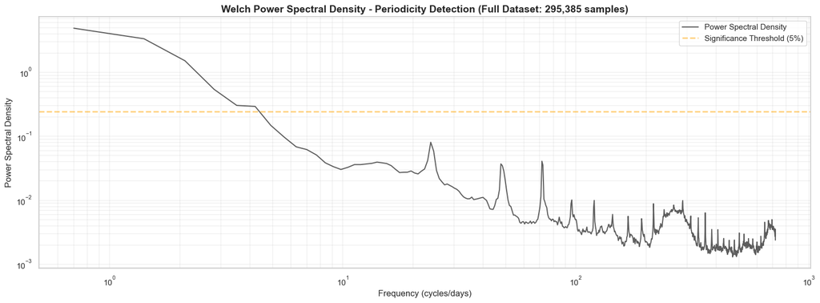

```
Interpretation Guide:
──────────────────────────────────────────────────────────────────────
• Sharp peaks: Strong, regular periodic components
• Broad peaks: Quasi-periodic patterns with some irregularity
• Flat spectrum: Non-periodic, irregular fluctuations
• Multiple peaks: Multi-scale periodic structure

Note: Periods shown in days
```